# Assignment 3 - Question 2-a-b full

## Assignment 3 - Question 2-1

### Preparing the dataset

Importing necessary libraries.

```python
## Setting environmental variable path for Basemap library files.
import os
os.environ['PROJ_LIB']= r'C:\Users\Longin\Anaconda3\Library\share'

from mpl_toolkits.basemap import Basemap
import matplotlib.pyplot as plt
import numpy as np
import csv
import networkx as nx
import pandas as pd
```

I have formatted the given file of Qatar's city locations, extracting only their coordinates into 2 columns to CSV file called **HW3_qatar_tsp_csv_formatted.**

```python
df0 = pd.read_csv("HW3_qatar_tsp_csv_formatted.csv", header=0, dtype={'user': object,'other':object},  encoding="UTF-8")

print(df0.shape)

df0.head(5)
```

```
(194, 2)
```

|  | lat | lon |
| --- | --- | --- |
| 0 | 24748.3333 | 50840.0000 |
| 1 | 24758.8889 | 51211.9444 |
| 2 | 24827.2222 | 51394.7222 |
| 3 | 24904.4444 | 51175.0000 |
| 4 | 24996.1111 | 51548.8889 |

As the cordinates primarily have been multiplied by 1000, I have adjusted them to their normal values, dividing by 1000. I have created two lists with latitude and longitude values.

```python
df1 = df0.copy()
df1['lat'] = df0['lat']/1000
df1['lon'] = df0['lon']/1000
latitudes = df1['lat'].tolist()
longitudes = df1['lon'].tolist()
```

## Question 2a

### Map & Scatter plot

I have plotted the cities location on a scatter plot and using Basemap library, which allowed me to underpin the map of Qatar state and nearby area.

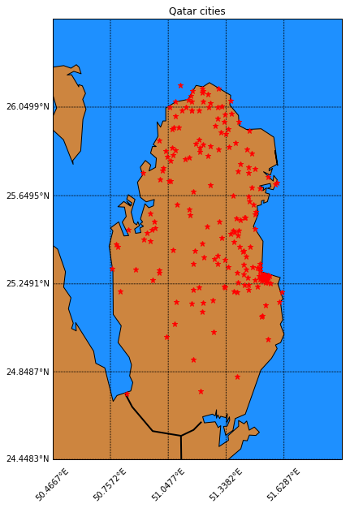

```python
zoom_scale = 0.3

# Setup the bounding box for the zoom and bounds of the map
a = [np.min(latitudes)-zoom_scale,np.max(latitudes)+zoom_scale,\
        np.min(longitudes)-zoom_scale,np.max(longitudes)+zoom_scale]

plt.figure(figsize=(10,10))
# Define the projection, scale, the corners of the map, and the resolution.
m = Basemap(projection='merc',llcrnrlat=a[0],urcrnrlat=a[1],\
            llcrnrlon=a[2],urcrnrlon=a[3],lat_ts=10,resolution='i')

# Draw coastlines and fill continents and water with color
m.drawcoastlines()
m.fillcontinents(color='peru',lake_color='dodgerblue')

# draw parallels, meridians, and color boundaries
m.drawparallels(np.arange(a[0],a[1],(a[1]-a[0])/5),labels=[1,0,0,0])
m.drawmeridians(np.arange(a[2],a[3],(a[3]-a[2])/5),labels=[0,0,0,1],rotation=45)
m.drawmapboundary(fill_color='dodgerblue')

#Drawing country boundaries
m.drawcountries(linewidth=2, linestyle='solid', color='k', antialiased=1, ax=None, zorder=None)

m.shadedrelief()

# build and plot coordinates onto map
x,y = m(longitudes,latitudes)
m.plot(x,y,'r*',color='red', markersize=7)
plt.title("Qatar cities")
plt.show()
```

### Distance matrix

```python
df3=df1.copy()
df3['coordinates'] = df3[['lat','lon']].apply(tuple, axis=1)
df3.head(5)
```

|  | lat | lon | coordinates |
| --- | --- | --- | --- |
| 0 | 24.748333 | 50.840000 | (24.7483333, 50.84) |
| 1 | 24.758889 | 51.211944 | (24.758888900000002, 51.2119444) |
| 2 | 24.827222 | 51.394722 | (24.8272222, 51.3947222) |
| 3 | 24.904444 | 51.175000 | (24.9044444, 51.175) |
| 4 | 24.996111 | 51.548889 | (24.996111099999997, 51.5488889) |

I have used the loop to calculate distances between each city.

```python
from haversine import haversine

dist_matrix = {}

def haver_loop(coords):
    for i, p1 in coords.iterrows():
        dist_matrix[i] = []
        for j, p2 in coords.iterrows():
            dist_matrix[i].append(haversine(p1.coordinates, p2.coordinates))

    return pd.DataFrame.from_dict(dist_matrix, orient='index')

distance_m = haver_loop(df3)
```

```python
distance_m.head(5)
```

|  | 0 | 1 | 2 | 3 | 4 | 5 | 6 | 7 | 8 | 9 | ... | 184 | 185 | 186 | 187 | 188 | 189 | 190 | 191 | 192 | 193 |
| --- | --- | --- | --- | --- | --- | --- | --- | --- | --- | --- | --- | --- | --- | --- | --- | --- | --- | --- | --- | --- | --- |
| 0 | 0.000000 | 37.576570 | 56.682236 | 38.003883 | 76.637405 | 35.374539 | 53.985375 | 42.841946 | 78.644757 | 79.265723 | ... | 156.866384 | 151.648259 | 153.688860 | 156.561523 | 156.782656 | 156.455267 | 157.680329 | 158.581160 | 160.782184 | 158.195442 |
| 1 | 37.576570 | 0.000000 | 19.954013 | 16.608904 | 43.024575 | 32.900257 | 30.906249 | 36.926168 | 48.813876 | 49.419223 | ... | 147.453491 | 147.445922 | 149.181425 | 150.056801 | 150.978956 | 151.811170 | 151.754293 | 152.832191 | 153.086967 | 155.066773 |
| 2 | 56.682236 | 19.954013 | 0.000000 | 23.772042 | 24.380352 | 41.190677 | 25.644821 | 41.693579 | 32.727911 | 33.262286 | ... | 139.126109 | 141.896849 | 143.426119 | 143.216183 | 144.489659 | 145.919310 | 145.181674 | 146.328695 | 145.544015 | 149.904436 |
| 3 | 38.003883 | 16.608904 | 23.772042 | 0.000000 | 39.048407 | 18.014239 | 17.311519 | 20.649956 | 40.723011 | 41.346576 | ... | 131.837799 | 131.147172 | 132.916320 | 134.018420 | 134.857992 | 135.566603 | 135.650092 | 136.710348 | 137.220864 | 138.693294 |
| 4 | 76.637405 | 43.024575 | 24.380352 | 39.048407 | 0.000000 | 51.362188 | 27.839694 | 48.156688 | 11.999317 | 12.233884 | ... | 121.764473 | 127.462565 | 128.734659 | 127.352176 | 128.980102 | 131.030917 | 129.569846 | 130.770694 | 128.894322 | 135.740669 |

5 rows × 194 columns

## Question 2b

### Travelling Salesman Problem using OR-TOOLS

Readjusting the data for the problem solving purposes.

```python
df4 = df3.copy()
df4['lat'] = df4['lat']*1000
df4['lon'] = df4['lon']*1000

df4['lat'] = df4['lat'].astype(int)
df4['lon'] = df4['lon'].astype(int)

df4['coordinates'] = df4[['lat','lon']].apply(tuple, axis=1)


df4.head(5)
```

|  | lat | lon | coordinates |
| --- | --- | --- | --- |
| 0 | 24748 | 50840 | (24748, 50840) |
| 1 | 24758 | 51211 | (24758, 51211) |
| 2 | 24827 | 51394 | (24827, 51394) |
| 3 | 24904 | 51175 | (24904, 51175) |
| 4 | 24996 | 51548 | (24996, 51548) |

### Best algorithm search

I have used the code from Google or-tools example and modified it to my exercise purposes. I will be changing to different optimisation algorithms to in order to find the best one, i.e. solution with the shortest path. I have created functions, which will reduce our code development and allowed me to reuse the code more oprtimally.

### Algorithm 1 - PATH_CHEAPEST_ARC

This algorithm starts from a route "start" node, in our case it will be point 0 of our data, then it connects to the node which is the closest. Further iterations will create solution.

```python
from __future__ import print_function
import math
import ortools
from ortools.constraint_solver import pywrapcp
from ortools.constraint_solver import routing_enums_pb2
```

Creating model data, with assigning cities from my previousle created dataframe. I have set number of vehicles as 1, as this is Travelling Salesman problem, i.e. we have one object visiting all the nodes. The depot is 0, so I am starting from node 0.

```python
def create_data_model():
    data = {}
    # Locations in block units
    data['locations'] = df4['coordinates']
    data['num_vehicles'] = 1
    data['depot'] = 0
    return data
```

I have recreate distance matrix for existing data.

```python
def compute_euclidean_distance_matrix(locations):
    distances = {}
    for from_counter, from_node in enumerate(locations):
        distances[from_counter] = {}
        for to_counter, to_node in enumerate(locations):
            if from_counter == to_counter:
                distances[from_counter][to_counter] = 0
            else:
                # Euclidean distance
                distances[from_counter][to_counter] = (int(
                    math.hypot((from_node[0] - to_node[0]),
                               (from_node[1] - to_node[1]))))
    return distances
```

I have used the google's printing function to show shortest path route in a written form.

```python
def print_route(manager, routing, assignment):
    print('Objective: {}'.format(assignment.ObjectiveValue()))
    index = routing.Start(0)
    plan_output = 'Route:\n'
    route_distance = 0
    while not routing.IsEnd(index):
        plan_output += ' {} ->'.format(manager.IndexToNode(index))
        previous_index = index
        index = assignment.Value(routing.NextVar(index))
        route_distance += routing.GetArcCostForVehicle(previous_index, index, 0)

    plan_output += ' {}\n'.format(manager.IndexToNode(index))
    print(plan_output)
    plan_output += 'Objective: {}m\n'.format(route_distance)
```

I have modified the above printing function to return a dataframe with 2 columns, representing graph edges.

```python
def print_as_graph(manager, routing, assignment):

    index = routing.Start(0)
    plan_output = ''
    route_distance = 0
    while not routing.IsEnd(index):
        plan_output += '{} '.format(manager.IndexToNode(index))
        previous_index = index
        index = assignment.Value(routing.NextVar(index))
        plan_output += '{}\n'.format(manager.IndexToNode(index))

    df = pd.DataFrame([x.split(' ') for x in plan_output.split('\n')])
    return df
```

I have modified google's code and used assignment's data to solve our problem.

```python
data = create_data_model()

manager = pywrapcp.RoutingIndexManager(len(data['locations']), data['num_vehicles'], data['depot'])

routing = pywrapcp.RoutingModel(manager)

distance_matrix = compute_euclidean_distance_matrix(data['locations'])

def distance_callback(from_index, to_index):
    from_node = manager.IndexToNode(from_index)
    to_node = manager.IndexToNode(to_index)
    return distance_matrix[from_node][to_node]

transit_callback_index = routing.RegisterTransitCallback(distance_callback)

routing.SetArcCostEvaluatorOfAllVehicles(transit_callback_index)

search_parameters = pywrapcp.DefaultRoutingSearchParameters()
search_parameters.first_solution_strategy = (routing_enums_pb2.FirstSolutionStrategy.PATH_CHEAPEST_ARC)

assignment = routing.SolveWithParameters(search_parameters)

if assignment:
    s_route = print_as_graph(manager, routing, assignment)
    print_route(manager, routing, assignment)
```

```
Objective: 9849
Route:
 0 -> 5 -> 7 -> 15 -> 35 -> 58 -> 61 -> 70 -> 75 -> 86 -> 79 -> 81 -> 88 -> 89 -> 93 -> 98 -> 100 -> 103 -> 110 -> 113 -> 112 -> 108 -> 101 -> 102 -> 90 -> 77 -> 74 -> 71 -> 73 -> 68 -> 59 -> 56 -> 63 -> 69 -> 67 -> 44 -> 36 -> 26 -> 21 -> 28 -> 27 -> 32 -> 17 -> 20 -> 23 -> 25 -> 16 -> 24 -> 22 -> …
```

I have used my print_as_graph function to create a dataframe representing the solution.

```python
s_route.rename(columns={0:'latitude', 1:'longitude',}, inplace=True)
s_route.head(5)
```

|  | latitude | longitude |
| --- | --- | --- |
| 0 | 0 | 5 |
| 1 | 5 | 7 |
| 2 | 7 | 15 |
| 3 | 15 | 35 |
| 4 | 35 | 58 |

I have used the solution data, wrote it to CSV file and create a graph object from it.

```python
s_route.to_csv('graph.csv', sep=' ', index=False, header=None, encoding='utf-8')
G = nx.Graph()
G = nx.read_edgelist("graph.csv", nodetype = str, create_using = nx.Graph(), data = (('weight', int),))
```

I have created a function to display the graphical solution of our Travelling Salesman Problem.

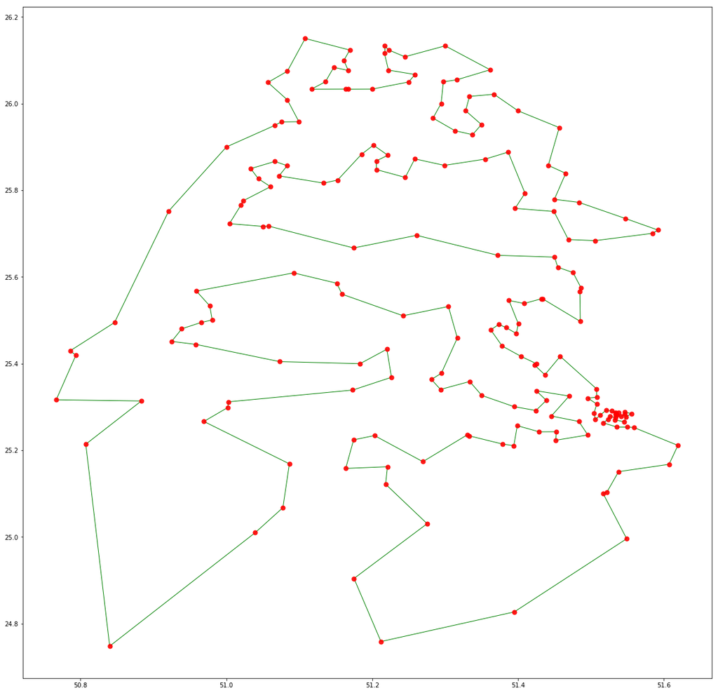

```python
def display(graph):

    plt.subplots(figsize=(20, 20))

    # Setting nodes positions
    values = df3[['lon','lat']].apply(np.array, axis=1)
    keys = df3.index.values.astype(str)
    pos1 = dict(zip(keys, values))

    #Nodes drawing
    nx.draw_networkx_nodes(graph, pos=pos1, node_color='red', node_size=50, alpha=0.9)

    #Edges drawing
    nx.draw_networkx_edges(graph, pos=pos1, edge_color='green', alpha=1)

    plt.show()

display(G)
```

### Algorithm 2 - Guided Local Search

I have changed the algorithm in order to look for more optimal solution: Algorithm guided local search - which enables the solver to escape a local minima. Solution that is shorter than all nearby routes, but which is not the global minimum.

```python
data = create_data_model()

# Create the routing index manager.
manager = pywrapcp.RoutingIndexManager(len(data['locations']), data['num_vehicles'], data['depot'])

# Create Routing Model.
routing = pywrapcp.RoutingModel(manager)

distance_matrix = compute_euclidean_distance_matrix(data['locations'])

def distance_callback(from_index, to_index):
    from_node = manager.IndexToNode(from_index)
    to_node = manager.IndexToNode(to_index)
    return distance_matrix[from_node][to_node]

transit_callback_index = routing.RegisterTransitCallback(distance_callback)

routing.SetArcCostEvaluatorOfAllVehicles(transit_callback_index)

search_parameters = pywrapcp.DefaultRoutingSearchParameters()
search_parameters.local_search_metaheuristic = (routing_enums_pb2.LocalSearchMetaheuristic.GUIDED_LOCAL_SEARCH)
search_parameters.time_limit.seconds = 60
search_parameters.log_search = True

assignment = routing.SolveWithParameters(search_parameters)

if assignment:
    s_route = print_as_graph(manager, routing, assignment)
    print_route(manager, routing, assignment)
```

```
Objective: 9450
Route:
 0 -> 3 -> 1 -> 2 -> 4 -> 8 -> 9 -> 11 -> 14 -> 18 -> 29 -> 31 -> 30 -> 33 -> 39 -> 42 -> 40 -> 37 -> 34 -> 41 -> 49 -> 54 -> 48 -> 43 -> 45 -> 47 -> 53 -> 51 -> 52 -> 55 -> 57 -> 46 -> 38 -> 50 -> 60 -> 66 -> 72 -> 65 -> 67 -> 63 -> 69 -> 76 -> 83 -> 80 -> 78 -> 82 -> 87 -> 92 -> 95 -> 94 -> 91 -> …
```

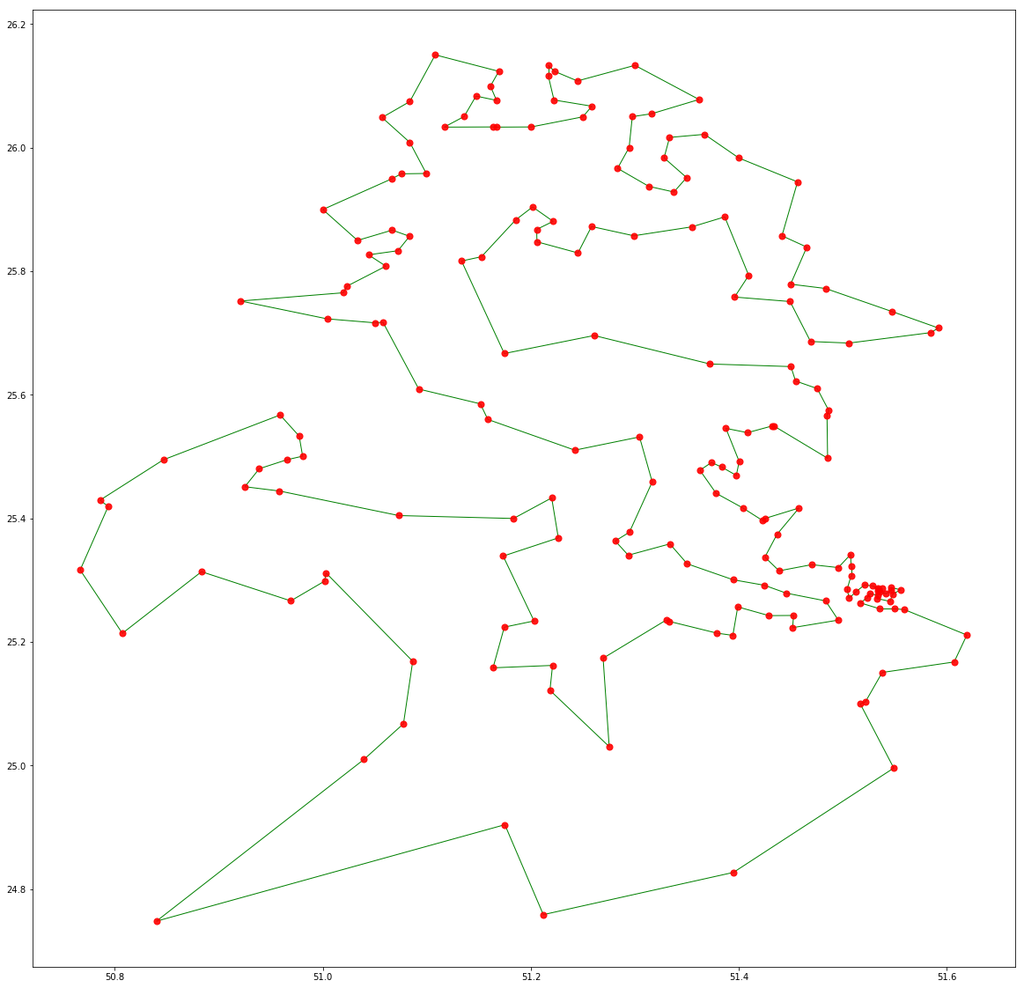

```python
s_route.to_csv('graph1.csv', sep=' ', index=False, header=None, encoding='utf-8')
G1 = nx.Graph()
G1 = nx.read_edgelist("graph1.csv", nodetype = str, create_using = nx.Graph(), data = (('weight', int),))
display(G1)
```